# Risk Factor Analysis

## Outcome Variable

**Outcome Variable:** haz

## Predictor Variables

**Intervention Variable:** meducyrs

**Adjustment Set:**

- arm
- W_mage
- feducyrs
- hhwealth_quart
- W_mhtcm
- W_mwtkg
- W_mbmi
- W_gagebrth
- W_birthwt
- W_birthlen
- single
- W_nrooms
- impsan
- delta_W_mage
- delta_feducyrs
- delta_hhwealth_quart
- delta_W_mhtcm
- delta_W_mwtkg
- delta_W_mbmi
- delta_W_gagebrth
- delta_W_birthwt
- delta_W_birthlen
- delta_single
- delta_W_nrooms
- delta_impsan

## Stratifying Variables

The analysis was stratified on these variable(s):

- agecat
- studyid
- country

## Data Summary

| agecat | studyid | country | meducyrs | n_cell | n | outcome_variable |
| --- | --- | --- | --- | --- | --- | --- |
| Birth | CMC-V-BCS-2002 | INDIA | High | 51 | 92 | haz |
| Birth | CMC-V-BCS-2002 | INDIA | Low | 16 | 92 | haz |
| Birth | CMC-V-BCS-2002 | INDIA | Medium | 25 | 92 | haz |
| Birth | COHORTS | GUATEMALA | High | 178 | 842 | haz |
| Birth | COHORTS | GUATEMALA | Low | 391 | 842 | haz |
| Birth | COHORTS | GUATEMALA | Medium | 273 | 842 | haz |
| Birth | COHORTS | INDIA | High | 678 | 5216 | haz |
| Birth | COHORTS | INDIA | Low | 1756 | 5216 | haz |
| Birth | COHORTS | INDIA | Medium | 2782 | 5216 | haz |
| Birth | COHORTS | PHILIPPINES | High | 1169 | 3050 | haz |
| Birth | COHORTS | PHILIPPINES | Low | 900 | 3050 | haz |
| Birth | COHORTS | PHILIPPINES | Medium | 981 | 3050 | haz |
| Birth | EE | PAKISTAN | High | 7 | 239 | haz |
| Birth | EE | PAKISTAN | Low | 215 | 239 | haz |
| Birth | EE | PAKISTAN | Medium | 17 | 239 | haz |
| Birth | GMS-Nepal | NEPAL | High | 85 | 693 | haz |
| Birth | GMS-Nepal | NEPAL | Low | 485 | 693 | haz |
| Birth | GMS-Nepal | NEPAL | Medium | 123 | 693 | haz |
| Birth | IRC | INDIA | High | 113 | 388 | haz |
| Birth | IRC | INDIA | Low | 142 | 388 | haz |
| Birth | IRC | INDIA | Medium | 133 | 388 | haz |
| Birth | JiVitA-3 | BANGLADESH | High | 6683 | 22427 | haz |
| Birth | JiVitA-3 | BANGLADESH | Low | 8795 | 22427 | haz |
| Birth | JiVitA-3 | BANGLADESH | Medium | 6949 | 22427 | haz |
| Birth | JiVitA-4 | BANGLADESH | High | 933 | 2817 | haz |
| Birth | JiVitA-4 | BANGLADESH | Low | 990 | 2817 | haz |
| Birth | JiVitA-4 | BANGLADESH | Medium | 894 | 2817 | haz |
| Birth | MAL-ED | BANGLADESH | High | 67 | 187 | haz |
| Birth | MAL-ED | BANGLADESH | Low | 65 | 187 | haz |
| Birth | MAL-ED | BANGLADESH | Medium | 55 | 187 | haz |

[output cut: 183 more lines]

The following strata were considered:

- agecat: 24 months, studyid: CMC-V-BCS-2002, country: INDIA
- agecat: 24 months, studyid: COHORTS, country: GUATEMALA
- agecat: 24 months, studyid: COHORTS, country: INDIA
- agecat: 24 months, studyid: COHORTS, country: PHILIPPINES
- agecat: 24 months, studyid: EE, country: PAKISTAN
- agecat: 24 months, studyid: GMS-Nepal, country: NEPAL
- agecat: 24 months, studyid: IRC, country: INDIA
- agecat: 24 months, studyid: JiVitA-3, country: BANGLADESH
- agecat: 24 months, studyid: JiVitA-4, country: BANGLADESH
- agecat: 24 months, studyid: LCNI-5, country: MALAWI
- agecat: 24 months, studyid: MAL-ED, country: BANGLADESH
- agecat: 24 months, studyid: MAL-ED, country: BRAZIL
- agecat: 24 months, studyid: MAL-ED, country: INDIA
- agecat: 24 months, studyid: MAL-ED, country: NEPAL
- agecat: 24 months, studyid: MAL-ED, country: PERU
- agecat: 24 months, studyid: MAL-ED, country: SOUTH AFRICA
- agecat: 24 months, studyid: MAL-ED, country: TANZANIA, UNITED REPUBLIC OF
- agecat: 24 months, studyid: NIH-Birth, country: BANGLADESH
- agecat: 24 months, studyid: NIH-Crypto, country: BANGLADESH
- agecat: 24 months, studyid: PROBIT, country: BELARUS
- agecat: 24 months, studyid: PROVIDE, country: BANGLADESH
- agecat: 24 months, studyid: TanzaniaChild2, country: TANZANIA, UNITED REPUBLIC OF
- agecat: 24 months, studyid: ZVITAMBO, country: ZIMBABWE
- agecat: 6 months, studyid: CMC-V-BCS-2002, country: INDIA
- agecat: 6 months, studyid: COHORTS, country: GUATEMALA
- agecat: 6 months, studyid: COHORTS, country: INDIA
- agecat: 6 months, studyid: COHORTS, country: PHILIPPINES
- agecat: 6 months, studyid: EE, country: PAKISTAN
- agecat: 6 months, studyid: GMS-Nepal, country: NEPAL
- agecat: 6 months, studyid: Guatemala BSC, country: GUATEMALA
- agecat: 6 months, studyid: IRC, country: INDIA
- agecat: 6 months, studyid: JiVitA-3, country: BANGLADESH
- agecat: 6 months, studyid: JiVitA-4, country: BANGLADESH
- agecat: 6 months, studyid: LCNI-5, country: MALAWI
- agecat: 6 months, studyid: MAL-ED, country: BANGLADESH
- agecat: 6 months, studyid: MAL-ED, country: BRAZIL
- agecat: 6 months, studyid: MAL-ED, country: INDIA
- agecat: 6 months, studyid: MAL-ED, country: NEPAL
- agecat: 6 months, studyid: MAL-ED, country: PERU
- agecat: 6 months, studyid: MAL-ED, country: SOUTH AFRICA
- agecat: 6 months, studyid: MAL-ED, country: TANZANIA, UNITED REPUBLIC OF
- agecat: 6 months, studyid: NIH-Birth, country: BANGLADESH
- agecat: 6 months, studyid: NIH-Crypto, country: BANGLADESH
- agecat: 6 months, studyid: PROBIT, country: BELARUS
- agecat: 6 months, studyid: PROVIDE, country: BANGLADESH
- agecat: 6 months, studyid: SAS-CompFeed, country: INDIA
- agecat: 6 months, studyid: SAS-FoodSuppl, country: INDIA
- agecat: 6 months, studyid: TanzaniaChild2, country: TANZANIA, UNITED REPUBLIC OF
- agecat: 6 months, studyid: ZVITAMBO, country: ZIMBABWE
- agecat: Birth, studyid: CMC-V-BCS-2002, country: INDIA
- agecat: Birth, studyid: COHORTS, country: GUATEMALA
- agecat: Birth, studyid: COHORTS, country: INDIA
- agecat: Birth, studyid: COHORTS, country: PHILIPPINES
- agecat: Birth, studyid: EE, country: PAKISTAN
- agecat: Birth, studyid: GMS-Nepal, country: NEPAL
- agecat: Birth, studyid: IRC, country: INDIA
- agecat: Birth, studyid: JiVitA-3, country: BANGLADESH
- agecat: Birth, studyid: JiVitA-4, country: BANGLADESH
- agecat: Birth, studyid: MAL-ED, country: BANGLADESH
- agecat: Birth, studyid: MAL-ED, country: BRAZIL
- agecat: Birth, studyid: MAL-ED, country: INDIA
- agecat: Birth, studyid: MAL-ED, country: NEPAL
- agecat: Birth, studyid: MAL-ED, country: PERU
- agecat: Birth, studyid: MAL-ED, country: SOUTH AFRICA
- agecat: Birth, studyid: MAL-ED, country: TANZANIA, UNITED REPUBLIC OF
- agecat: Birth, studyid: NIH-Birth, country: BANGLADESH
- agecat: Birth, studyid: NIH-Crypto, country: BANGLADESH
- agecat: Birth, studyid: PROBIT, country: BELARUS
- agecat: Birth, studyid: PROVIDE, country: BANGLADESH
- agecat: Birth, studyid: SAS-CompFeed, country: INDIA
- agecat: Birth, studyid: ZVITAMBO, country: ZIMBABWE

### Dropped Strata

Some strata were dropped due to rare outcomes:

- agecat: 24 months, studyid: TanzaniaChild2, country: TANZANIA, UNITED REPUBLIC OF

## Methods Detail

We’re interested in the causal parameters $E[Y_a]$ for all values of $a \in \mathcal{A}$. These parameters represent the mean outcome if, possibly contrary to fact, we intervened to set all units to have $A=a$. Under the randomization and positivity assumptions, these are identified by the statistical parameters $\psi_a=E_W[E_{Y|A,W}(Y|A=a,W)]$. In addition, we’re interested in the mean of $Y$, $E[Y]$ under no intervention (the observed mean). We will estimate these parameters by using SuperLearner to fit the relevant likelihood factors – $E_{Y|A,W}(Y|A=a,W)$ and $p(A=a|W)$, and then updating our likelihood fit using a joint TMLE.

For unadjusted analyses ($W=\{\}$), initial likelihoods were estimated using Lrnr_glm to estimate the simple $E(Y|A)$ and Lrnr_mean to estimate $p(A)$. For adjusted analyses, a small library containing Lrnr_glmnet, Lrnr_xgboost, and Lrnr_mean was used.

Having estimated these parameters, we will then use the delta method to estimate relative risks and attributable risks relative to a prespecified baseline level of $A$.

# Results Detail

## Results Plots

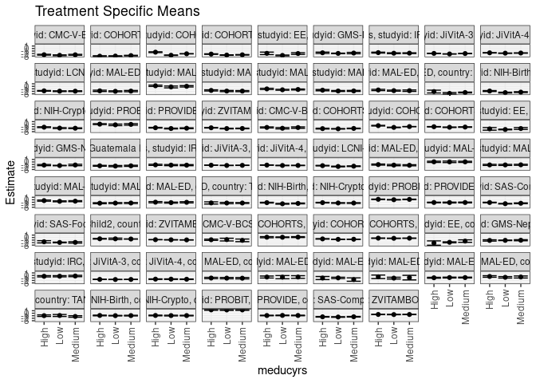

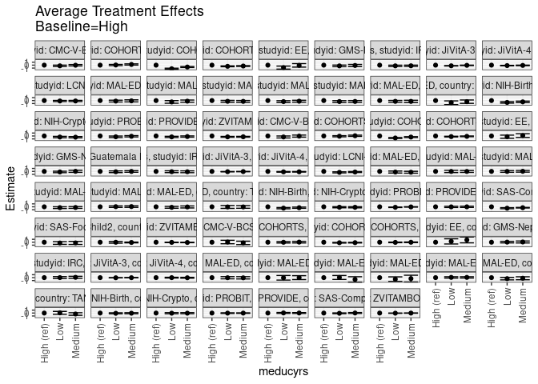

[figure not shown]

## Results Table

### Parameter: TSM

| agecat | studyid | country | intervention_level | baseline_level | estimate | ci_lower | ci_upper |
| --- | --- | --- | --- | --- | --- | --- | --- |
| Birth | CMC-V-BCS-2002 | INDIA | High | NA | -0.8631786 | -1.1158102 | -0.6105469 |
| Birth | CMC-V-BCS-2002 | INDIA | Low | NA | -0.7999396 | -1.3357558 | -0.2641234 |
| Birth | CMC-V-BCS-2002 | INDIA | Medium | NA | -1.0981701 | -1.6262806 | -0.5700596 |
| Birth | COHORTS | GUATEMALA | High | NA | 0.1571302 | -0.0584685 | 0.3727289 |
| Birth | COHORTS | GUATEMALA | Low | NA | 0.1406951 | 0.0154899 | 0.2659003 |
| Birth | COHORTS | GUATEMALA | Medium | NA | 0.1951990 | 0.0182020 | 0.3721961 |
| Birth | COHORTS | INDIA | High | NA | -0.5166191 | -0.6172514 | -0.4159868 |
| Birth | COHORTS | INDIA | Low | NA | -0.6901243 | -0.7606805 | -0.6195682 |
| Birth | COHORTS | INDIA | Medium | NA | -0.6623172 | -0.7087010 | -0.6159334 |
| Birth | COHORTS | PHILIPPINES | High | NA | -0.2291727 | -0.3065435 | -0.1518020 |
| Birth | COHORTS | PHILIPPINES | Low | NA | -0.2851510 | -0.3642972 | -0.2060048 |
| Birth | COHORTS | PHILIPPINES | Medium | NA | -0.2408867 | -0.3183300 | -0.1634434 |
| Birth | EE | PAKISTAN | High | NA | -2.1742857 | -3.0389611 | -1.3096103 |
| Birth | EE | PAKISTAN | Low | NA | -1.8810233 | -2.0830133 | -1.6790332 |
| Birth | EE | PAKISTAN | Medium | NA | -1.3876471 | -1.8873432 | -0.8879509 |
| Birth | GMS-Nepal | NEPAL | High | NA | -1.1381613 | -1.3927305 | -0.8835920 |
| Birth | GMS-Nepal | NEPAL | Low | NA | -1.0997799 | -1.1966600 | -1.0028997 |
| Birth | GMS-Nepal | NEPAL | Medium | NA | -1.0532635 | -1.2765149 | -0.8300121 |
| Birth | IRC | INDIA | High | NA | -0.3396981 | -0.5943627 | -0.0850335 |
| Birth | IRC | INDIA | Low | NA | -0.3305369 | -0.5675297 | -0.0935442 |
| Birth | IRC | INDIA | Medium | NA | -0.2403040 | -0.5133197 | 0.0327117 |
| Birth | JiVitA-3 | BANGLADESH | High | NA | -1.5869823 | -1.6249420 | -1.5490225 |
| Birth | JiVitA-3 | BANGLADESH | Low | NA | -1.6324536 | -1.6649056 | -1.6000017 |
| Birth | JiVitA-3 | BANGLADESH | Medium | NA | -1.6061747 | -1.6420076 | -1.5703417 |
| Birth | JiVitA-4 | BANGLADESH | High | NA | -1.4796740 | -1.5808133 | -1.3785347 |
| Birth | JiVitA-4 | BANGLADESH | Low | NA | -1.4856084 | -1.5848218 | -1.3863950 |
| Birth | JiVitA-4 | BANGLADESH | Medium | NA | -1.5226469 | -1.6279172 | -1.4173765 |
| Birth | MAL-ED | BANGLADESH | High | NA | -1.0516972 | -1.3251047 | -0.7782897 |
| Birth | MAL-ED | BANGLADESH | Low | NA | -1.0846428 | -1.3505764 | -0.8187092 |
| Birth | MAL-ED | BANGLADESH | Medium | NA | -1.1165763 | -1.3956187 | -0.8375338 |

[output cut: 180 more lines]

### Parameter: E(Y)

| agecat | studyid | country | intervention_level | baseline_level | estimate | ci_lower | ci_upper |
| --- | --- | --- | --- | --- | --- | --- | --- |
| Birth | CMC-V-BCS-2002 | INDIA | NA | NA | -0.9611957 | -1.1776967 | -0.7446946 |
| Birth | COHORTS | GUATEMALA | NA | NA | 0.1288717 | 0.0445170 | 0.2132265 |
| Birth | COHORTS | INDIA | NA | NA | -0.6688842 | -0.7003528 | -0.6374156 |
| Birth | COHORTS | PHILIPPINES | NA | NA | -0.2490492 | -0.2880580 | -0.2100404 |
| Birth | EE | PAKISTAN | NA | NA | -1.8545188 | -2.0422173 | -1.6668203 |
| Birth | GMS-Nepal | NEPAL | NA | NA | -1.0877489 | -1.1679913 | -1.0075066 |
| Birth | IRC | INDIA | NA | NA | -0.3080412 | -0.4687931 | -0.1472894 |
| Birth | JiVitA-3 | BANGLADESH | NA | NA | -1.5897102 | -1.6089975 | -1.5704229 |
| Birth | JiVitA-4 | BANGLADESH | NA | NA | -1.5232552 | -1.5724840 | -1.4740265 |
| Birth | MAL-ED | BANGLADESH | NA | NA | -1.0884492 | -1.2349987 | -0.9418997 |
| Birth | MAL-ED | BRAZIL | NA | NA | -0.6760000 | -0.9521457 | -0.3998543 |
| Birth | MAL-ED | INDIA | NA | NA | -1.2372500 | -1.5471753 | -0.9273247 |
| Birth | MAL-ED | NEPAL | NA | NA | -0.9120000 | -1.2873301 | -0.5366699 |
| Birth | MAL-ED | PERU | NA | NA | -0.8827897 | -1.0001058 | -0.7654736 |
| Birth | MAL-ED | SOUTH AFRICA | NA | NA | -0.6317073 | -0.8249555 | -0.4384591 |
| Birth | MAL-ED | TANZANIA, UNITED REPUBLIC OF | NA | NA | -1.1398095 | -1.3671021 | -0.9125169 |
| Birth | NIH-Birth | BANGLADESH | NA | NA | -0.9310197 | -1.0197391 | -0.8423003 |
| Birth | NIH-Crypto | BANGLADESH | NA | NA | -0.9094945 | -0.9809370 | -0.8380521 |
| Birth | PROBIT | BELARUS | NA | NA | 1.3114417 | 1.1524752 | 1.4704082 |
| Birth | PROVIDE | BANGLADESH | NA | NA | -0.8851020 | -0.9601332 | -0.8100709 |
| Birth | SAS-CompFeed | INDIA | NA | NA | -1.4314217 | -1.5099245 | -1.3529189 |
| Birth | ZVITAMBO | ZIMBABWE | NA | NA | -0.5006712 | -0.5212382 | -0.4801043 |
| 6 months | CMC-V-BCS-2002 | INDIA | NA | NA | -1.4234508 | -1.5645974 | -1.2823042 |
| 6 months | COHORTS | GUATEMALA | NA | NA | -1.8103361 | -1.8786415 | -1.7420307 |
| 6 months | COHORTS | INDIA | NA | NA | -1.0183078 | -1.0495042 | -0.9871113 |
| 6 months | COHORTS | PHILIPPINES | NA | NA | -1.1405724 | -1.1824954 | -1.0986493 |
| 6 months | EE | PAKISTAN | NA | NA | -2.0782207 | -2.1981595 | -1.9582820 |
| 6 months | GMS-Nepal | NEPAL | NA | NA | -1.3508616 | -1.4293975 | -1.2723256 |
| 6 months | Guatemala BSC | GUATEMALA | NA | NA | -1.5624368 | -1.6783540 | -1.4465196 |
| 6 months | IRC | INDIA | NA | NA | -1.2344062 | -1.3658524 | -1.1029600 |
| 6 months | JiVitA-3 | BANGLADESH | NA | NA | -1.3131339 | -1.3362896 | -1.2899781 |
| 6 months | JiVitA-4 | BANGLADESH | NA | NA | -1.3449232 | -1.3822755 | -1.3075709 |
| 6 months | LCNI-5 | MALAWI | NA | NA | -1.6431488 | -1.7125598 | -1.5737379 |
| 6 months | MAL-ED | BANGLADESH | NA | NA | -1.1932738 | -1.3246079 | -1.0619397 |
| 6 months | MAL-ED | BRAZIL | NA | NA | 0.0494712 | -0.0951008 | 0.1940431 |
| 6 months | MAL-ED | INDIA | NA | NA | -1.1605449 | -1.2821450 | -1.0389448 |
| 6 months | MAL-ED | NEPAL | NA | NA | -0.5481599 | -0.6614541 | -0.4348656 |
| 6 months | MAL-ED | PERU | NA | NA | -1.3277482 | -1.4358597 | -1.2196367 |
| 6 months | MAL-ED | SOUTH AFRICA | NA | NA | -1.0633202 | -1.1909180 | -0.9357224 |
| 6 months | MAL-ED | TANZANIA, UNITED REPUBLIC OF | NA | NA | -1.2937438 | -1.4246923 | -1.1627954 |
| 6 months | NIH-Birth | BANGLADESH | NA | NA | -1.4073821 | -1.4960598 | -1.3187043 |
| 6 months | NIH-Crypto | BANGLADESH | NA | NA | -1.1986783 | -1.2700937 | -1.1272630 |
| 6 months | PROBIT | BELARUS | NA | NA | 0.0980074 | 0.0062724 | 0.1897424 |
| 6 months | PROVIDE | BANGLADESH | NA | NA | -1.0916915 | -1.1661176 | -1.0172654 |
| 6 months | SAS-CompFeed | INDIA | NA | NA | -1.4018563 | -1.4810585 | -1.3226541 |
| 6 months | SAS-FoodSuppl | INDIA | NA | NA | -1.8986842 | -2.0118892 | -1.7854792 |
| 6 months | TanzaniaChild2 | TANZANIA, UNITED REPUBLIC OF | NA | NA | -0.5440108 | -0.5930025 | -0.4950192 |
| 6 months | ZVITAMBO | ZIMBABWE | NA | NA | -0.8688556 | -0.8944357 | -0.8432754 |
| 24 months | CMC-V-BCS-2002 | INDIA | NA | NA | -2.5588679 | -2.6583730 | -2.4593629 |
| 24 months | COHORTS | GUATEMALA | NA | NA | -2.9885052 | -3.0530889 | -2.9239215 |
| 24 months | COHORTS | INDIA | NA | NA | -2.1741663 | -2.2109368 | -2.1373958 |
| 24 months | COHORTS | PHILIPPINES | NA | NA | -2.4141145 | -2.4590818 | -2.3691473 |
| 24 months | EE | PAKISTAN | NA | NA | -2.6563232 | -2.8000905 | -2.5125560 |
| 24 months | GMS-Nepal | NEPAL | NA | NA | -1.8887629 | -1.9746814 | -1.8028444 |
| 24 months | IRC | INDIA | NA | NA | -1.7987775 | -1.8923914 | -1.7051636 |
| 24 months | JiVitA-3 | BANGLADESH | NA | NA | -2.0134370 | -2.0411067 | -1.9857672 |
| 24 months | JiVitA-4 | BANGLADESH | NA | NA | -1.7814786 | -1.8170130 | -1.7459442 |
| 24 months | LCNI-5 | MALAWI | NA | NA | -1.8795105 | -1.9611410 | -1.7978800 |
| 24 months | MAL-ED | BANGLADESH | NA | NA | -1.9096199 | -2.0438307 | -1.7754091 |
| 24 months | MAL-ED | BRAZIL | NA | NA | 0.0081448 | -0.1615145 | 0.1778041 |
| 24 months | MAL-ED | INDIA | NA | NA | -1.8274372 | -1.9559249 | -1.6989495 |
| 24 months | MAL-ED | NEPAL | NA | NA | -1.2688028 | -1.3908231 | -1.1467825 |
| 24 months | MAL-ED | PERU | NA | NA | -1.7545083 | -1.8762212 | -1.6327955 |
| 24 months | MAL-ED | SOUTH AFRICA | NA | NA | -1.6450595 | -1.7797240 | -1.5103950 |
| 24 months | MAL-ED | TANZANIA, UNITED REPUBLIC OF | NA | NA | -2.5654000 | -2.7089193 | -2.4218807 |
| 24 months | NIH-Birth | BANGLADESH | NA | NA | -2.2190579 | -2.3217459 | -2.1163699 |
| 24 months | NIH-Crypto | BANGLADESH | NA | NA | -1.4412646 | -1.5249156 | -1.3576135 |
| 24 months | PROBIT | BELARUS | NA | NA | -0.1442891 | -0.4253755 | 0.1367972 |
| 24 months | PROVIDE | BANGLADESH | NA | NA | -1.6024221 | -1.6857420 | -1.5191023 |
| 24 months | ZVITAMBO | ZIMBABWE | NA | NA | -1.6059152 | -1.6629321 | -1.5488983 |

### Parameter: ATE

| agecat | studyid | country | intervention_level | baseline_level | estimate | ci_lower | ci_upper |
| --- | --- | --- | --- | --- | --- | --- | --- |
| Birth | CMC-V-BCS-2002 | INDIA | High | High | 0.0000000 | 0.0000000 | 0.0000000 |
| Birth | CMC-V-BCS-2002 | INDIA | Low | High | 0.0632390 | -0.5317346 | 0.6582125 |
| Birth | CMC-V-BCS-2002 | INDIA | Medium | High | -0.2349915 | -0.8270482 | 0.3570652 |
| Birth | COHORTS | GUATEMALA | High | High | 0.0000000 | 0.0000000 | 0.0000000 |
| Birth | COHORTS | GUATEMALA | Low | High | -0.0164351 | -0.2660221 | 0.2331519 |
| Birth | COHORTS | GUATEMALA | Medium | High | 0.0380688 | -0.2412159 | 0.3173536 |
| Birth | COHORTS | INDIA | High | High | 0.0000000 | 0.0000000 | 0.0000000 |
| Birth | COHORTS | INDIA | Low | High | -0.1735053 | -0.2951644 | -0.0518461 |
| Birth | COHORTS | INDIA | Medium | High | -0.1456981 | -0.2551375 | -0.0362588 |
| Birth | COHORTS | PHILIPPINES | High | High | 0.0000000 | 0.0000000 | 0.0000000 |
| Birth | COHORTS | PHILIPPINES | Low | High | -0.0559782 | -0.1646318 | 0.0526753 |
| Birth | COHORTS | PHILIPPINES | Medium | High | -0.0117140 | -0.1188185 | 0.0953906 |
| Birth | EE | PAKISTAN | High | High | 0.0000000 | 0.0000000 | 0.0000000 |
| Birth | EE | PAKISTAN | Low | High | 0.2932625 | -0.5946922 | 1.1812171 |
| Birth | EE | PAKISTAN | Medium | High | 0.7866387 | -0.2120403 | 1.7853176 |
| Birth | GMS-Nepal | NEPAL | High | High | 0.0000000 | 0.0000000 | 0.0000000 |
| Birth | GMS-Nepal | NEPAL | Low | High | 0.0383814 | -0.2322327 | 0.3089954 |
| Birth | GMS-Nepal | NEPAL | Medium | High | 0.0848978 | -0.2521963 | 0.4219918 |
| Birth | IRC | INDIA | High | High | 0.0000000 | 0.0000000 | 0.0000000 |
| Birth | IRC | INDIA | Low | High | 0.0091612 | -0.3204417 | 0.3387641 |
| Birth | IRC | INDIA | Medium | High | 0.0993941 | -0.2547738 | 0.4535621 |
| Birth | JiVitA-3 | BANGLADESH | High | High | 0.0000000 | 0.0000000 | 0.0000000 |
| Birth | JiVitA-3 | BANGLADESH | Low | High | -0.0454714 | -0.0903740 | -0.0005687 |
| Birth | JiVitA-3 | BANGLADESH | Medium | High | -0.0191924 | -0.0665913 | 0.0282065 |
| Birth | JiVitA-4 | BANGLADESH | High | High | 0.0000000 | 0.0000000 | 0.0000000 |
| Birth | JiVitA-4 | BANGLADESH | Low | High | -0.0059344 | -0.1476270 | 0.1357582 |
| Birth | JiVitA-4 | BANGLADESH | Medium | High | -0.0429729 | -0.1932779 | 0.1073322 |
| Birth | MAL-ED | BANGLADESH | High | High | 0.0000000 | 0.0000000 | 0.0000000 |
| Birth | MAL-ED | BANGLADESH | Low | High | -0.0329456 | -0.4155930 | 0.3497018 |
| Birth | MAL-ED | BANGLADESH | Medium | High | -0.0648791 | -0.4568316 | 0.3270734 |

[output cut: 180 more lines]

### Parameter: PAR

| agecat | studyid | country | intervention_level | baseline_level | estimate | ci_lower | ci_upper |
| --- | --- | --- | --- | --- | --- | --- | --- |
| Birth | CMC-V-BCS-2002 | INDIA | High | NA | -0.0980171 | -0.3047502 | 0.1087160 |
| Birth | COHORTS | GUATEMALA | High | NA | -0.0282585 | -0.2314182 | 0.1749012 |
| Birth | COHORTS | INDIA | High | NA | -0.1522651 | -0.2499779 | -0.0545523 |
| Birth | COHORTS | PHILIPPINES | High | NA | -0.0198764 | -0.0866061 | 0.0468532 |
| Birth | EE | PAKISTAN | High | NA | 0.3197669 | -0.5399412 | 1.1794750 |
| Birth | GMS-Nepal | NEPAL | High | NA | 0.0504123 | -0.1949298 | 0.2957544 |
| Birth | IRC | INDIA | High | NA | 0.0316569 | -0.1783063 | 0.2416201 |
| Birth | JiVitA-3 | BANGLADESH | High | NA | -0.0027279 | -0.0357786 | 0.0303228 |
| Birth | JiVitA-4 | BANGLADESH | High | NA | -0.0435812 | -0.1331649 | 0.0460024 |
| Birth | MAL-ED | BANGLADESH | High | NA | -0.0367520 | -0.2686424 | 0.1951384 |
| Birth | MAL-ED | BRAZIL | High | NA | -0.0306102 | -0.4475644 | 0.3863441 |
| Birth | MAL-ED | INDIA | High | NA | -0.1885000 | -0.7564850 | 0.3794850 |
| Birth | MAL-ED | NEPAL | High | NA | -0.3560000 | -1.0206118 | 0.3086118 |
| Birth | MAL-ED | PERU | High | NA | 0.0577194 | -0.0873708 | 0.2028097 |
| Birth | MAL-ED | SOUTH AFRICA | High | NA | -0.2111365 | -0.4901103 | 0.0678374 |
| Birth | MAL-ED | TANZANIA, UNITED REPUBLIC OF | High | NA | -0.1726667 | -0.5399274 | 0.1945941 |
| Birth | NIH-Birth | BANGLADESH | High | NA | -0.0444499 | -0.1585324 | 0.0696326 |
| Birth | NIH-Crypto | BANGLADESH | High | NA | -0.0196602 | -0.1372512 | 0.0979308 |
| Birth | PROBIT | BELARUS | High | NA | -0.0257064 | -0.1026522 | 0.0512395 |
| Birth | PROVIDE | BANGLADESH | High | NA | 0.0266464 | -0.0671626 | 0.1204553 |
| Birth | SAS-CompFeed | INDIA | High | NA | -0.0042465 | -0.1286424 | 0.1201495 |
| Birth | ZVITAMBO | ZIMBABWE | High | NA | -0.0122746 | -0.0365546 | 0.0120055 |
| 6 months | CMC-V-BCS-2002 | INDIA | High | NA | -0.1098724 | -0.2747233 | 0.0549784 |
| 6 months | COHORTS | GUATEMALA | High | NA | -0.0251370 | -0.1834376 | 0.1331635 |
| 6 months | COHORTS | INDIA | High | NA | -0.4138653 | -0.5332372 | -0.2944934 |
| 6 months | COHORTS | PHILIPPINES | High | NA | -0.1069827 | -0.1792966 | -0.0346688 |
| 6 months | EE | PAKISTAN | High | NA | -0.1883178 | -0.6994136 | 0.3227780 |
| 6 months | GMS-Nepal | NEPAL | High | NA | -0.1032294 | -0.3226291 | 0.1161702 |
| 6 months | Guatemala BSC | GUATEMALA | High | NA | -0.0387382 | -0.1726654 | 0.0951891 |
| 6 months | IRC | INDIA | High | NA | -0.0772978 | -0.2635054 | 0.1089098 |
| 6 months | JiVitA-3 | BANGLADESH | High | NA | -0.0217902 | -0.0597856 | 0.0162051 |
| 6 months | JiVitA-4 | BANGLADESH | High | NA | -0.0969870 | -0.1580500 | -0.0359241 |
| 6 months | LCNI-5 | MALAWI | High | NA | -0.1673152 | -0.2641742 | -0.0704562 |
| 6 months | MAL-ED | BANGLADESH | High | NA | -0.1542586 | -0.3443479 | 0.0358308 |
| 6 months | MAL-ED | BRAZIL | High | NA | -0.0055972 | -0.2028011 | 0.1916067 |
| 6 months | MAL-ED | INDIA | High | NA | 0.0169135 | -0.1749434 | 0.2087705 |
| 6 months | MAL-ED | NEPAL | High | NA | -0.2158543 | -0.4220414 | -0.0096673 |
| 6 months | MAL-ED | PERU | High | NA | 0.0415620 | -0.1223422 | 0.2054662 |
| 6 months | MAL-ED | SOUTH AFRICA | High | NA | -0.1029156 | -0.3104958 | 0.1046645 |
| 6 months | MAL-ED | TANZANIA, UNITED REPUBLIC OF | High | NA | -0.0380031 | -0.4665502 | 0.3905440 |
| 6 months | NIH-Birth | BANGLADESH | High | NA | -0.2600268 | -0.3880583 | -0.1319953 |
| 6 months | NIH-Crypto | BANGLADESH | High | NA | -0.0575056 | -0.1691616 | 0.0541505 |
| 6 months | PROBIT | BELARUS | High | NA | -0.0840917 | -0.1398991 | -0.0282843 |
| 6 months | PROVIDE | BANGLADESH | High | NA | -0.0075570 | -0.1235315 | 0.1084175 |
| 6 months | SAS-CompFeed | INDIA | High | NA | -0.3122289 | -0.4009204 | -0.2235375 |
| 6 months | SAS-FoodSuppl | INDIA | High | NA | -0.2241884 | -0.6545617 | 0.2061848 |
| 6 months | TanzaniaChild2 | TANZANIA, UNITED REPUBLIC OF | High | NA | -0.0636008 | -0.1628312 | 0.0356297 |
| 6 months | ZVITAMBO | ZIMBABWE | High | NA | -0.0354172 | -0.0613489 | -0.0094856 |
| 24 months | CMC-V-BCS-2002 | INDIA | High | NA | -0.0753379 | -0.1974660 | 0.0467903 |
| 24 months | COHORTS | GUATEMALA | High | NA | 0.0776101 | -0.0814954 | 0.2367157 |
| 24 months | COHORTS | INDIA | High | NA | -0.7136472 | -0.8682529 | -0.5590415 |
| 24 months | COHORTS | PHILIPPINES | High | NA | -0.1923152 | -0.2804505 | -0.1041800 |
| 24 months | EE | PAKISTAN | High | NA | -0.7263232 | -1.2203870 | -0.2322594 |
| 24 months | GMS-Nepal | NEPAL | High | NA | -0.1843831 | -0.4338711 | 0.0651050 |
| 24 months | IRC | INDIA | High | NA | -0.1567639 | -0.3040724 | -0.0094555 |
| 24 months | JiVitA-3 | BANGLADESH | High | NA | -0.0609929 | -0.1125701 | -0.0094157 |
| 24 months | JiVitA-4 | BANGLADESH | High | NA | -0.0662298 | -0.1261005 | -0.0063591 |
| 24 months | LCNI-5 | MALAWI | High | NA | -0.0827357 | -0.1914694 | 0.0259979 |
| 24 months | MAL-ED | BANGLADESH | High | NA | -0.1045874 | -0.2978373 | 0.0886625 |
| 24 months | MAL-ED | BRAZIL | High | NA | -0.2070599 | -0.4269402 | 0.0128204 |
| 24 months | MAL-ED | INDIA | High | NA | -0.1948825 | -0.3953832 | 0.0056182 |
| 24 months | MAL-ED | NEPAL | High | NA | -0.2374953 | -0.4624413 | -0.0125492 |
| 24 months | MAL-ED | PERU | High | NA | -0.2227813 | -0.4319176 | -0.0136450 |
| 24 months | MAL-ED | SOUTH AFRICA | High | NA | -0.1906440 | -0.4085252 | 0.0272372 |
| 24 months | MAL-ED | TANZANIA, UNITED REPUBLIC OF | High | NA | -0.4711143 | -1.0216088 | 0.0793802 |
| 24 months | NIH-Birth | BANGLADESH | High | NA | -0.3414168 | -0.4950884 | -0.1877452 |
| 24 months | NIH-Crypto | BANGLADESH | High | NA | -0.2246791 | -0.3481190 | -0.1012392 |
| 24 months | PROBIT | BELARUS | High | NA | -0.1478055 | -0.3574028 | 0.0617919 |
| 24 months | PROVIDE | BANGLADESH | High | NA | -0.1672524 | -0.2820592 | -0.0524456 |
| 24 months | ZVITAMBO | ZIMBABWE | High | NA | -0.1520123 | -0.2081615 | -0.0958632 |